# Plate reader growth curves of GAT201 mutants in RPMI media varying NaHCO3

Liz Hughes & Edward Wallace

19/02/2024

# Summary

This experiments tests the effect of sodium bicarbonate (NaHCO3) on growth of Cryptococcus neoformans.

Plate reader growth curves of WT KN99-alpha and gat201∆ deletion mutant Madhani in RPMI media with no phenol red, and varying NaHCO3 concentrations.

- 3 Bioreps (1 per plate), 3 Techreps each.
- Grow 5ml culture from colony (1 colony = 1 Biorep) in YPD, 30C, 180 rpm ON.
- Seed at OD 600nm = 0.2 , 200 ul per well.
- Run for 1 day / 24 hours at 37C
- With 4 concentrations of NaHCO3: 0mM, 1.5mM, 6mM, 24mM

Data in files, one per biological replicate plate:

- `20240112_SubGoal4_BR1_repeat.xlsx`
- `20240112_SubGoal4_BR2_repeat.xlsx`
- `20240112_SG4_BR3.xlsx`

# Set up data frame of nice strain names, colours, styles.

```r
strain_df <- tibble( Strain      = c("KN99-1", "KN99-2", "Gat201(M)", "C1", "C2" ),
                     Strain_nice = c("GAT201", "GAT201", "gat201∆m", "GAT201-C1", "GAT201-C2"),
                     colour      = c("grey20", "grey20", "darkred", "blue3", "cyan4"))
```

```r
media_df <- tibble( Medium      = as_factor(c("RPMI-N", "RPMI-1.5mM", "RPMI-6mM", "RPMI-24mM" )),
                    NaHCO3_mM   = c(0, 1.5, 6, 24),
                    NaHCO3_mMfac   = c(0, 1.5, 6, 24) %>% paste0("mM") %>% as_factor())
```

## Read in the Plate map data from csv file RPMI

Also combine with nice strain names for display.

```r
platemap <-
  here::here("data", "20240116_SG4_Plate-Setup.csv") %>%
  read_platemap_csv(strain_df = strain_df) %>%
  left_join(media_df, by = "Medium")

head(platemap, n=10)
```

```
## # A tibble: 10 × 9
##    Well  Strain Biorep Techrep Medium Strain_nice colour NaHCO3_mM NaHCO3_mMfac
##    <chr> <chr>   <dbl>   <dbl> <chr>  <chr>       <chr>      <dbl> <fct>
##  1 A1    <NA>       NA      NA RPMI-N <NA>        <NA>           0 0mM
##  2 A2    <NA>       NA      NA RPMI-N <NA>        <NA>           0 0mM
##  3 A3    <NA>       NA      NA RPMI-N <NA>        <NA>           0 0mM
##  4 A4    <NA>       NA      NA RPMI-N <NA>        <NA>           0 0mM
##  5 A5    <NA>       NA      NA RPMI-N <NA>        <NA>           0 0mM
##  6 A6    <NA>       NA      NA RPMI-N <NA>        <NA>           0 0mM
##  7 A7    <NA>       NA      NA RPMI-N <NA>        <NA>           0 0mM
##  8 A8    <NA>       NA      NA RPMI-N <NA>        <NA>           0 0mM
##  9 A9    <NA>       NA      NA RPMI-N <NA>        <NA>           0 0mM
## 10 A10   <NA>       NA      NA RPMI-N <NA>        <NA>           0 0mM
```

# Analysis, biological replicate 1

## Read in raw data

```r
raw_od_BR1 <-
  here::here("data", "20240112_SubGoal4_BR1_repeat.xlsx") %>%
  read_platereader_xlsx(start_row = 52) %>%
  filter(!is.na(Time))
```

## Reshape data and combine with the plate map, pairing them by Well

```r
annotated_od_BR1 <-
  reshape_annotate_raw_od(raw_od = raw_od_BR1, platemap = platemap)
```

## Plot blank ODs

To find how stable the ODs of the blank wells are.

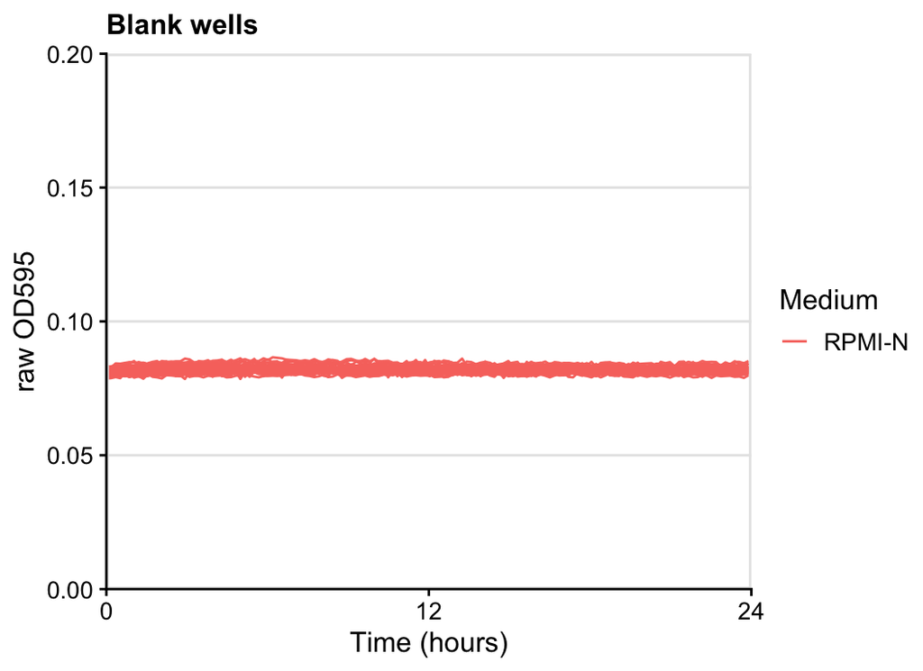

```r
ggplot(data=filter(annotated_od_BR1, is.na(Strain)),
       aes(x=Time, y=OD595,  group = Well, colour = Medium)) +
  geom_line() +
  scale_time_hrs(limits = c(0,24)) +
  scale_y_continuous(limits = c(0, 0.2),
                     expand = c(0, 0),
                     breaks = c(0, 0.05, 0.1, 0.15, 0.2)) +
  labs(title = "Blank wells", x="Time (hours)", y="raw OD595")
```

This shows that OD of blank wells is stable.

## Calculate median OD for blank wells

```r
blank_od_summary <-
  annotated_od_BR1 %>%
  dplyr::group_by(Medium) %>%
  summarise_od_fixed(od.name = "OD595",
                     is.na(Strain))

print(blank_od_summary)
```

```
## # A tibble: 1 × 5
## # Groups:   Medium [1]
##   Medium OD_median OD_mean OD_max OD_min
##   <chr>      <dbl>   <dbl>  <dbl>  <dbl>
## 1 RPMI-N    0.0817  0.0819 0.0866 0.0785
```

```r
blank_od_time <-
  annotated_od_BR1 %>%
  dplyr::group_by(Medium) %>%
  summarise_od_bytime(od.name = "OD595",
                     is.na(Strain),
                     !is.na(OD595))

print(blank_od_time)
```

[output not shown]

## Subtract blank OD to make corrected OD

```r
normalised_od_BR1 <-
  annotated_od_BR1 %>%
  normalise_od_2ways(is.na(Strain))
```

## Plot OD corrected

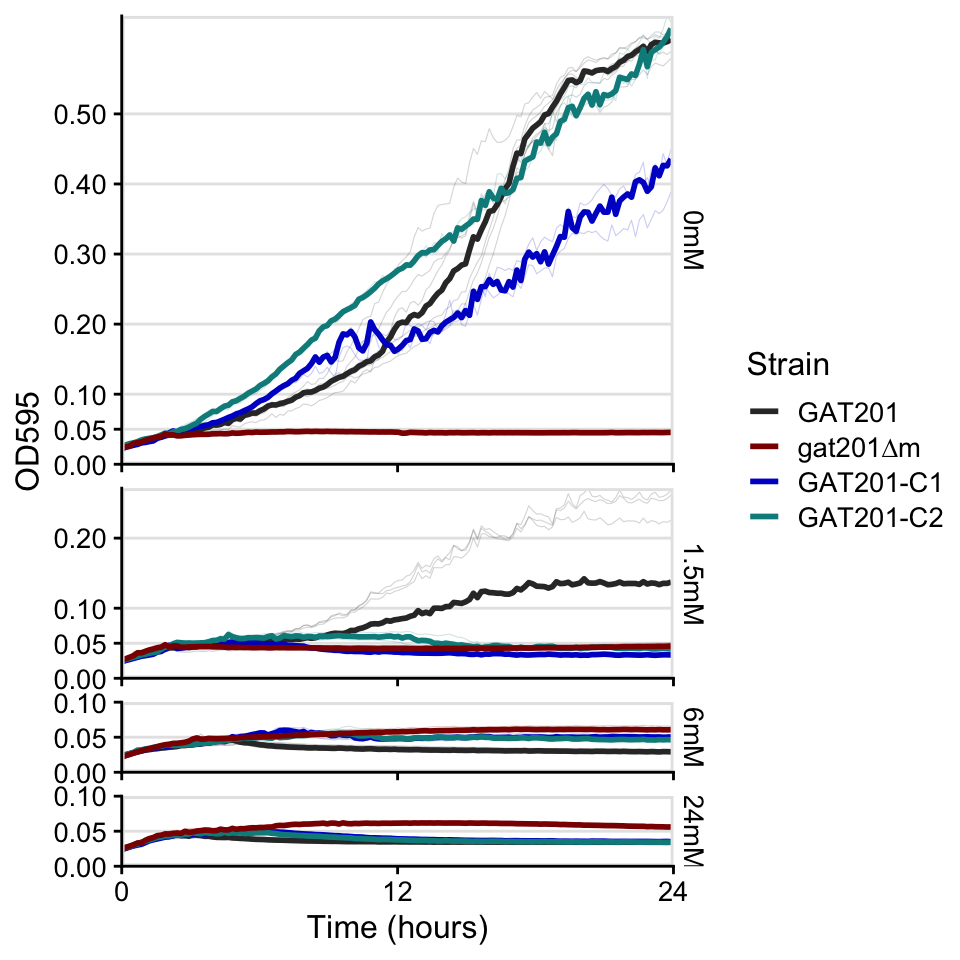

```r
plot_BR1 <-
  ggplot_growthcurve_summary(data_od = normalised_od_BR1 %>%
                               filter(!is.na(Strain)),
                             value_od = "OD_corrected_fixed",
                             limits_time = c(0,24),
                             limits_od = NULL,
                             breaks_od = c(0, 0.05, 0.1, 0.2, 0.3, 0.4, 0.5)) +
  scale_color_strain(strain_df) +
  expand_limits(y = c(0, 0.1)) +
  facet_rep_grid(NaHCO3_mMfac ~.,
                 scales = "free_y",
                 space = "free_y")

plot_BR1
```

## Plot OD corrected, with smoothing spline

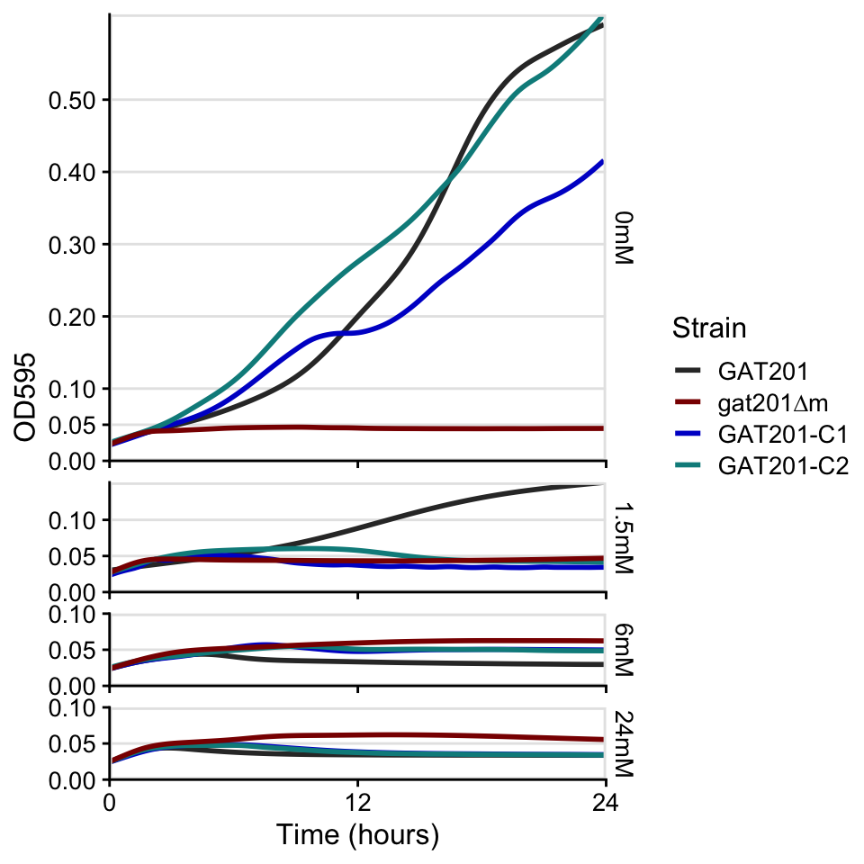

```r
spline_plot_BR1 <-
  ggplot_growthcurve_spline(data_od = normalised_od_BR1 %>%
                               filter(!is.na(Strain)),
                             value_od = "OD_corrected_fixed",
                             limits_time = c(0,24),
                             limits_od = NULL,
                             breaks_od = c(0, 0.05, 0.1, 0.2, 0.3, 0.4, 0.5)) +
  scale_color_strain(strain_df) +
  expand_limits(y = c(0, 0.1)) +
  facet_rep_grid(NaHCO3_mMfac ~.,
                 scales = "free_y",
                 space = "free_y")

spline_plot_BR1
```

# Biological Replicate 2

## Read in raw data, reshape, annotate, normalise

```r
raw_od_BR2 <-
  here::here("data", "20240112_SubGoal4_BR2_repeat.xlsx") %>%
  read_platereader_xlsx(start_row = 52) %>%
  filter(!is.na(Time))

annotated_od_BR2 <-
  reshape_annotate_raw_od(raw_od = raw_od_BR2, platemap = platemap)

normalised_od_BR2 <-
  annotated_od_BR2 %>%
  normalise_od_2ways(is.na(Strain))
```

## Check blank ODs

To find how stable the ODs of the blank wells are.

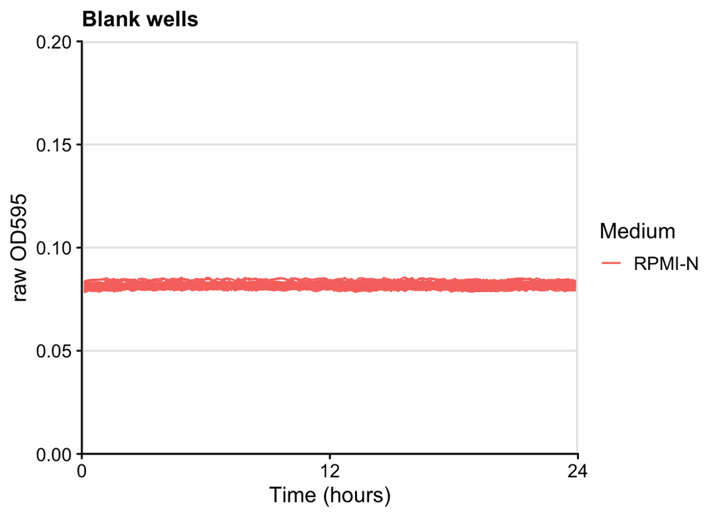

```r
ggplot(data=filter(annotated_od_BR2, is.na(Strain)),
       aes(x=Time, y=OD595,  group = Well, colour = Medium)) +
  geom_line() +
  scale_time_hrs(limits = c(0,24)) +
  scale_y_continuous(limits = c(0, 0.2),
                     expand = c(0, 0),
                     breaks = c(0, 0.05, 0.1, 0.15, 0.2)) +
  labs(title = "Blank wells", x="Time (hours)", y="raw OD595")
```

This shows that OD of blank wells is stable.

## Plot OD corrected, with smoothing spline

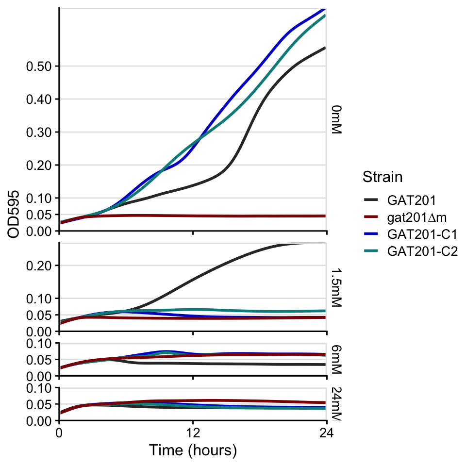

```r
spline_plot_BR2 <-
  ggplot_growthcurve_spline(data_od = normalised_od_BR2 %>%
                               filter(!is.na(Strain)),
                             value_od = "OD_corrected_fixed",
                             limits_time = c(0,24),
                             limits_od = NULL,
                             breaks_od = c(0, 0.05, 0.1, 0.2, 0.3, 0.4, 0.5)) +
  scale_color_strain(strain_df) +
  expand_limits(y = c(0, 0.1)) +
  facet_rep_grid(NaHCO3_mMfac ~.,
                 scales = "free_y",
                 space = "free_y")

spline_plot_BR2
```

# Biological Replicate 3

## Read in raw data, reshape, annotate, normalise

```r
raw_od_BR3 <-
  here::here("data", "20240112_SG4_BR3.xlsx") %>%
  read_platereader_xlsx(start_row = 56) %>%
  filter(!is.na(Time))

annotated_od_BR3 <-
  reshape_annotate_raw_od(raw_od = raw_od_BR3, platemap = platemap)

normalised_od_BR3 <-
  annotated_od_BR3 %>%
  normalise_od_2ways(is.na(Strain))
```

## Check blank ODs

To find how stable the ODs of the blank wells are.

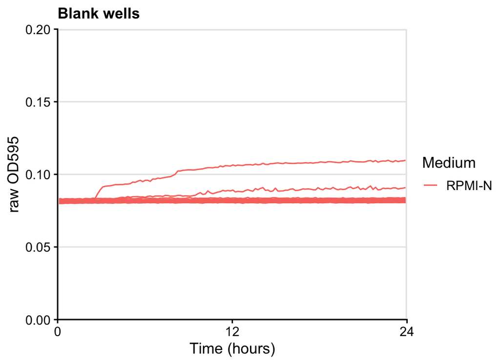

```r
ggplot(data=filter(annotated_od_BR3, is.na(Strain)),
       aes(x=Time, y=OD595,  group = Well, colour = Medium)) +
  geom_line() +
  scale_time_hrs(limits = c(0,24)) +
  scale_y_continuous(limits = c(0, 0.2),
                     expand = c(0, 0),
                     breaks = c(0, 0.05, 0.1, 0.15, 0.2)) +
  labs(title = "Blank wells", x="Time (hours)", y="raw OD595")
```

This shows that OD of blank wells is mostly stable, except 2 that are behaving badly. Using the median for normalisation means these won’t affect the next steps of analysis.

## Plot OD corrected, with smoothing spline

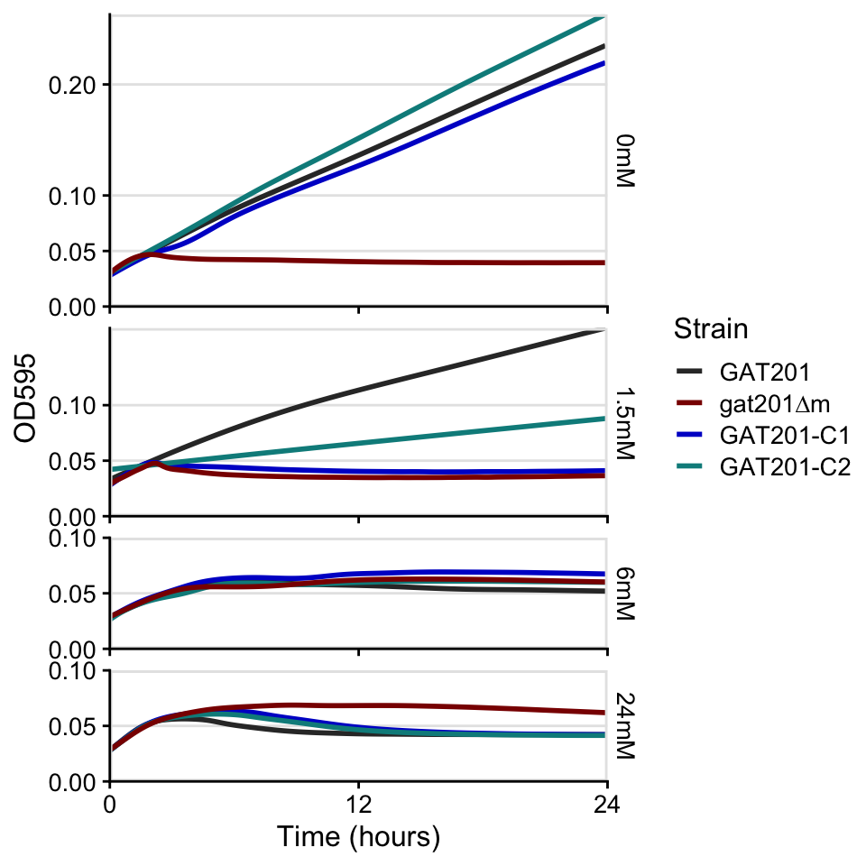

```r
spline_plot_BR3 <-
  ggplot_growthcurve_spline(data_od = normalised_od_BR3 %>%
                               filter(!is.na(Strain)),
                             value_od = "OD_corrected_fixed",
                             limits_time = c(0,24),
                             limits_od = NULL,
                             breaks_od = c(0, 0.05, 0.1, 0.2, 0.3, 0.4, 0.5)) +
  scale_color_strain(strain_df) +
  expand_limits(y = c(0, 0.1)) +
  facet_rep_grid(NaHCO3_mMfac ~.,
                 scales = "free_y",
                 space = "free_y")

spline_plot_BR3
```

```r
ggsave(filename = here::here("results", "fig_growthcurves_varyingNaHCO3_BioRep3.png"),
       plot = spline_plot_BR3, height = 5, width = 5)

ggsave(filename = here::here("results", "fig_growthcurves_varyingNaHCO3_BioRep3.svg"),
       plot = spline_plot_BR3, height = 5, width = 5)
```

# Plot to show all replicates

## Collect all 3 reps into single data frame

```r
normalised_od_allreps <-
  bind_rows(normalised_od_BR1 %>% mutate(BioRep = "Biol. Rep. 1"),
            normalised_od_BR2 %>% mutate(BioRep = "Biol. Rep. 2"),
            normalised_od_BR3 %>% mutate(BioRep = "Biol. Rep. 3"),
            )
```

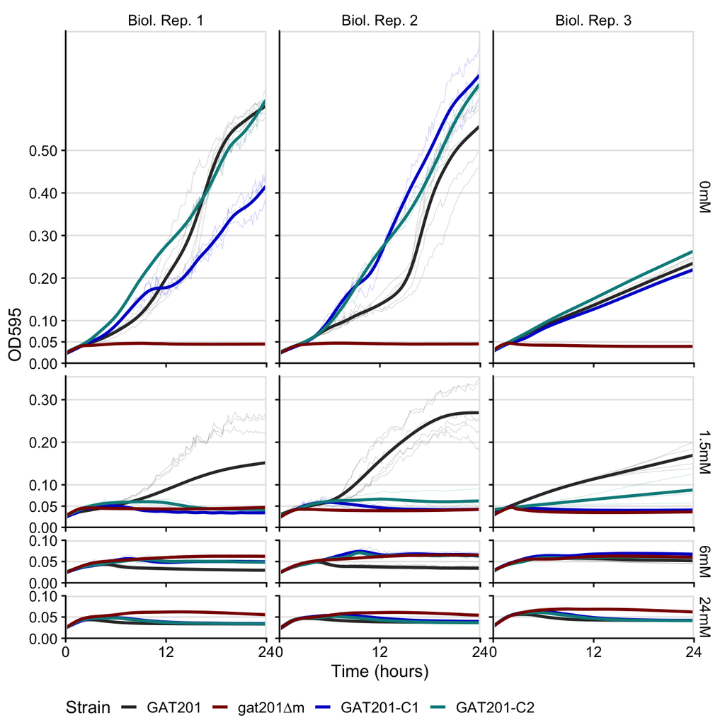

```r
plot_allreps <-
  ggplot_growthcurve_spline_pluswells(data_od = normalised_od_allreps %>%
                               filter(!is.na(Strain)),
                             value_od = "OD_corrected_fixed",
                             limits_time = c(0,24),
                             limits_od = NULL,
                             breaks_od = c(0, 0.05, 0.1, 0.2, 0.3, 0.4, 0.5)) +
  scale_color_strain(strain_df) +
  expand_limits(y = c(0, 0.1)) +
  facet_rep_grid(NaHCO3_mMfac ~ BioRep,
                 scales = "free_y",
                 space = "free_y") +
  theme(legend.position = "bottom")

plot_allreps
```

```r
ggsave(filename = here::here("results", "fig_growthcurves_varyingNaHCO3_allreps.png"),
       plot = plot_allreps, height = 6.5, width = 6.5)
```